# Mediation and moderation Demo

PSY 597 Week 12

Michael Hallquist

9 Apr 2019

Code for this demo adapted from Nick Michalak. Also see https://nickmichalak.com/post/2019-02-14-testing-conditional-indirect-effects-mediation-in-r/testing-conditional-indirect-effects-mediation-in-r/

# 1 Example dataset

The dataset for this example contains standardized test scores on reading, writing, math, science, and social studies. There are also binary indicators (e.g., `hisci`) that encode whether someone received a high score on a given test. We also want to compute centered versions of each variable to aid interpretation in moderation-related models.

Following Hayes, I will use the convention $X$ for independent variable/predictor, $M$ for mediator, $W$ for moderator, and $Y$ for outcome.

```r
df <- read_csv("mediation_data.csv")
df <- df %>% mutate_at(vars(read, write, math, science, socst), funs(c=scale))
```

# 2 Moderation with a continuous moderator

Hayes Process model 1

Does the relationship between performance on reading ($Y$) and social studies ($X$) tests depend on math ability ($W$)?

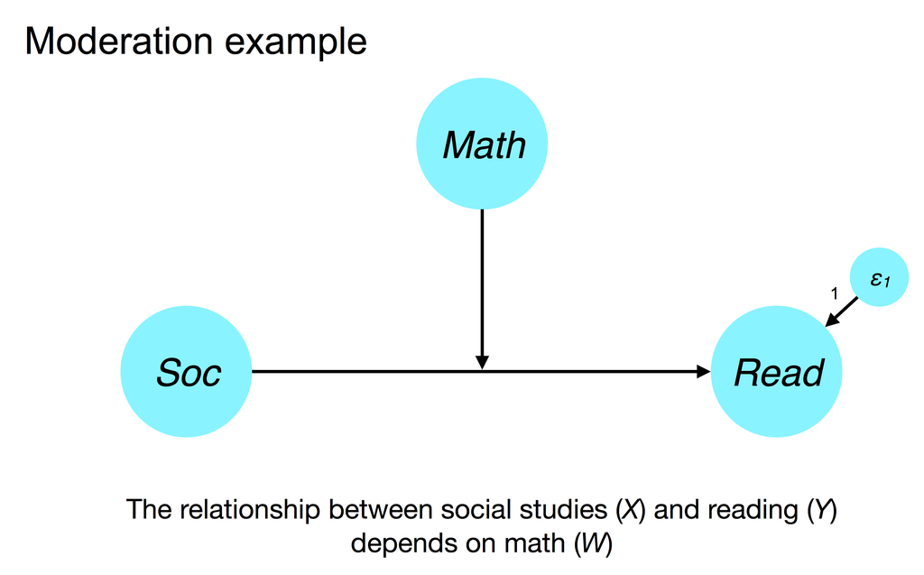

```r
library(lavaan)

# create interaction term between centered X (socst) and W (math)
df <- df %>% mutate(socst_x_math = socst_c * math_c)

# parameters
moderation_model <- '
  # regressions
  read ~ b1*socst_c
  read ~ b2*math_c
  read ~ b3*socst_x_math

  # define mean parameter label for centered math for use in simple slopes
  math_c ~ math.mean*1

  # define variance parameter label for centered math for use in simple slopes
  math_c ~~ math.var*math_c

  # simple slopes for condition effect
  SD.below := b1 + b3*(math.mean - sqrt(math.var))
  mean := b1 + b3*(math.mean)
  SD.above := b1 + b3*(math.mean + sqrt(math.var))
  '

# fit the model using nonparametric bootstrapping (this takes some time)
sem1 <- sem(model = moderation_model,
            data = df,
            se = "bootstrap",
            bootstrap = 1000)
# fit measures
summary(sem1, fit.measures = TRUE, standardized = TRUE, rsquare = TRUE)
```

```
## lavaan 0.6-3 ended normally after 34 iterations
##
##   Optimization method                           NLMINB
##   Number of free parameters                         12
##
##   Number of observations                           200
##
##   Estimator                                         ML
##   Model Fit Test Statistic                      76.103
##   Degrees of freedom                                 2
##   P-value (Chi-square)                           0.000
##
## Model test baseline model:
##
##   Minimum Function Test Statistic              234.093
##   Degrees of freedom                                 5
##   P-value                                        0.000
##
## User model versus baseline model:
##
##   Comparative Fit Index (CFI)                    0.677
##   Tucker-Lewis Index (TLI)                       0.191
##
## Loglikelihood and Information Criteria:
##
##   Loglikelihood user model (H0)              -1509.766
##   Loglikelihood unrestricted model (H1)      -1471.714
##
##   Number of free parameters                         12
##   Akaike (AIC)                                3043.531
##   Bayesian (BIC)                              3083.111
##   Sample-size adjusted Bayesian (BIC)         3045.094
##
## Root Mean Square Error of Approximation:
##
##   RMSEA                                          0.430
##   90 Percent Confidence Interval          0.351  0.516
##   P-value RMSEA <= 0.05                          0.000
##
## Standardized Root Mean Square Residual:
```

[output cut: 29 more lines]

```
##                    Estimate  Std.Err  z-value  P(>|z|)   Std.lv  Std.all
##     math_c  (mth.)    0.995    0.082   12.090    0.000    0.995    1.000
##    .read             47.473    4.698   10.105    0.000   47.473    0.564
##     socst_c           0.995    0.091   10.909    0.000    0.995    1.000
##     scst_x_           0.908    0.106    8.567    0.000    0.908    1.000
##
## R-Square:
##                    Estimate
##     read              0.436
##
## Defined Parameters:
##                    Estimate  Std.Err  z-value  P(>|z|)   Std.lv  Std.all
##     SD.below          2.882    0.724    3.981    0.000    2.882    0.319
##     mean              4.013    0.584    6.875    0.000    4.013    0.437
##     SD.above          5.145    0.812    6.339    0.000    5.145    0.554
```

```r
#compute bias-corrected estimates of bootstrapped confidence intervals
parameterEstimates(sem1, boot.ci.type = "bca.simple",
                   level = .95, ci = TRUE, standardized = FALSE)
```

| lhs | op | rhs | label | est | se | z | pvalue | ci.lower | ci.upper |
| --- | --- | --- | --- | --- | --- | --- | --- | --- | --- |
| read | ~ | socst_c | b1 | 4.013 | 0.571 | 7.029 | 0.000 | 2.890 | 5.253 |
| read | ~ | math_c | b2 | 4.503 | 0.603 | 7.466 | 0.000 | 3.282 | 5.709 |
| read | ~ | socst_x_math | b3 | 1.135 | 0.503 | 2.254 | 0.024 | 0.115 | 2.143 |
| math_c | ~1 |  | math.mean | 0.000 | 0.070 | 0.000 | 1.000 | -0.131 | 0.147 |
| math_c | ~~ | math_c | math.var | 0.995 | 0.082 | 12.090 | 0.000 | 0.846 | 1.168 |
| read | ~~ | read |  | 47.473 | 4.698 | 10.105 | 0.000 | 39.123 | 58.338 |
| socst_c | ~~ | socst_c |  | 0.995 | 0.091 | 10.909 | 0.000 | 0.827 | 1.194 |
| socst_c | ~~ | socst_x_math |  | -0.082 | 0.101 | -0.807 | 0.419 | -0.296 | 0.096 |
| socst_x_math | ~~ | socst_x_math |  | 0.908 | 0.106 | 8.567 | 0.000 | 0.713 | 1.130 |
| read | ~1 |  |  | 51.615 | 0.585 | 88.240 | 0.000 | 50.541 | 52.796 |
| socst_c | ~1 |  |  | 0.000 | 0.072 | 0.000 | 1.000 | -0.138 | 0.140 |
| socst_x_math | ~1 |  |  | 0.542 | 0.069 | 7.846 | 0.000 | 0.413 | 0.682 |
| SD.below | := | b1+b3*(math.mean-sqrt(math.var)) | SD.below | 2.882 | 0.724 | 3.981 | 0.000 | 1.523 | 4.310 |
| mean | := | b1+b3*(math.mean) | mean | 4.013 | 0.584 | 6.875 | 0.000 | 2.868 | 5.293 |
| SD.above | := | b1+b3*(math.mean+sqrt(math.var)) | SD.above | 5.145 | 0.812 | 6.339 | 0.000 | 3.530 | 6.693 |

# 3 Simple mediation

Hayes Process model 4

Is the relationship between `science` and `math` mediated by `read`?

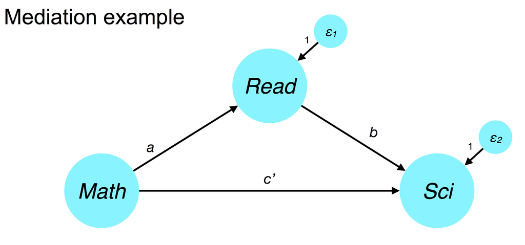

```r
# parameters
mediation_model <- '
    # direct effect
      science ~ cp*math_c
      direct := cp

    # regressions
      read_c ~ a*math_c
      science ~ b*read_c

    # indirect effect (a*b)
      indirect := a*b

    # total effect
      total := cp + (a*b)
'

# fit model
sem2 <- sem(model = mediation_model, data = df, se = "bootstrap", bootstrap = 1000)
# fit measures
summary(sem2, fit.measures = TRUE, standardize = TRUE, rsquare = TRUE)
```

```
## lavaan 0.6-3 ended normally after 27 iterations
##
##   Optimization method                           NLMINB
##   Number of free parameters                          5
##
##   Number of observations                           200
##
##   Estimator                                         ML
##   Model Fit Test Statistic                       0.000
##   Degrees of freedom                                 0
##
## Model test baseline model:
##
##   Minimum Function Test Statistic              245.569
##   Degrees of freedom                                 3
##   P-value                                        0.000
##
## User model versus baseline model:
##
##   Comparative Fit Index (CFI)                    1.000
##   Tucker-Lewis Index (TLI)                       1.000
##
## Loglikelihood and Information Criteria:
##
##   Loglikelihood user model (H0)               -902.313
##   Loglikelihood unrestricted model (H1)       -902.313
##
##   Number of free parameters                          5
##   Akaike (AIC)                                1814.627
##   Bayesian (BIC)                              1831.118
##   Sample-size adjusted Bayesian (BIC)         1815.278
##
## Root Mean Square Error of Approximation:
##
##   RMSEA                                          0.000
##   90 Percent Confidence Interval          0.000  0.000
##   P-value RMSEA <= 0.05                             NA
##
## Standardized Root Mean Square Residual:
##
```

[output cut: 17 more lines]

```
## Variances:
##                    Estimate  Std.Err  z-value  P(>|z|)   Std.lv  Std.all
##    .science          50.894    4.935   10.314    0.000   50.894    0.522
##    .read_c            0.559    0.054   10.389    0.000    0.559    0.561
##
## R-Square:
##                    Estimate
##     science           0.478
##     read_c            0.439
##
## Defined Parameters:
##                    Estimate  Std.Err  z-value  P(>|z|)   Std.lv  Std.all
##     direct            3.763    0.770    4.885    0.000    3.763    0.380
##     indirect          2.481    0.501    4.950    0.000    2.481    0.251
##     total             6.245    0.518   12.052    0.000    6.245    0.631
```

# 4 First-stage moderated mediation

Does the indirect effect of `math` ($X$) on `science` ($Y$) via `read` ($M$) depend on `write` ($W$)? More specifically, does writing ability moderate the relationship betwen math and reading? For example, perhaps only people with high writing and math ability tend to score higher on a reading test. If this is true, then the indirect effect of math on science via reading depends on writing as well.

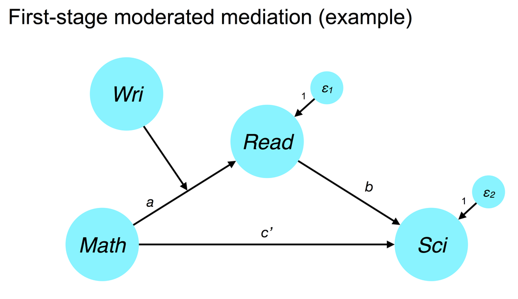

```r
#compute math x writing interaction term
df <- df %>% mutate(math_x_write = math_c*write_c)

moderated_mediation_1 <- '
  # regressions
    read_c ~ a1*math_c
    science ~ b*read_c
    read_c ~ a2*write_c
    read_c ~ a3*math_x_write
    science ~ cdash*math_c

  # mean of centered write (for use in simple slopes)
    write_c ~ write.mean*1

  # variance of centered write (for use in simple slopes)
    write_c ~~ write.var*write_c

  # index of moderated mediation
    imm := a3*b

  # indirect effects conditional on moderator (a1 + a3*a2.value)*b
    indirect.SDbelow := a1*b + a3*-sqrt(write.var)*b
    indirect.mean := a1*b + a3*write.mean*b
    indirect.SDabove := a1*b + a3*sqrt(write.var)*b

'

# fit model
sem3 <- sem(model = moderated_mediation_1, data = df, se = "bootstrap", bootstrap = 1000)
# fit measures
summary(sem3, fit.measures = TRUE, standardize = TRUE, rsquare = TRUE)
```

```
## lavaan 0.6-3 ended normally after 32 iterations
##
##   Optimization method                           NLMINB
##   Number of free parameters                         16
##
##   Number of observations                           200
##
##   Estimator                                         ML
##   Model Fit Test Statistic                     119.179
##   Degrees of freedom                                 4
##   P-value (Chi-square)                           0.000
##
## Model test baseline model:
##
##   Minimum Function Test Statistic              386.622
##   Degrees of freedom                                 9
##   P-value                                        0.000
##
## User model versus baseline model:
##
##   Comparative Fit Index (CFI)                    0.695
##   Tucker-Lewis Index (TLI)                       0.314
##
## Loglikelihood and Information Criteria:
##
##   Loglikelihood user model (H0)              -1718.688
##   Loglikelihood unrestricted model (H1)      -1659.098
##
##   Number of free parameters                         16
##   Akaike (AIC)                                3469.376
##   Bayesian (BIC)                              3522.149
##   Sample-size adjusted Bayesian (BIC)         3471.459
##
## Root Mean Square Error of Approximation:
##
##   RMSEA                                          0.379
##   90 Percent Confidence Interval          0.323  0.440
##   P-value RMSEA <= 0.05                          0.000
##
## Standardized Root Mean Square Residual:
```

[output cut: 38 more lines]

[output not shown]

```r
#compute bias-corrected confidence intervals
parameterEstimates(sem3, boot.ci.type = "bca.simple", level = .95, ci = TRUE, standardized = FALSE)
```

| lhs | op | rhs | label | est | se | z | pvalue | ci.lower | ci.upper |
| --- | --- | --- | --- | --- | --- | --- | --- | --- | --- |
| read_c | ~ | math_c | a1 | 0.464 | 0.068 | 6.794 | 0.000 | 0.327 | 0.587 |
| science | ~ | read_c | b | 3.747 | 0.782 | 4.792 | 0.000 | 2.073 | 5.198 |
| read_c | ~ | write_c | a2 | 0.315 | 0.065 | 4.841 | 0.000 | 0.194 | 0.448 |
| read_c | ~ | math_x_write | a3 | 0.039 | 0.055 | 0.713 | 0.476 | -0.071 | 0.143 |
| science | ~ | math_c | cdash | 3.763 | 0.786 | 4.786 | 0.000 | 2.308 | 5.410 |
| write_c | ~1 |  | write.mean | 0.000 | 0.072 | 0.000 | 1.000 | -0.137 | 0.143 |
| write_c | ~~ | write_c | write.var | 0.995 | 0.080 | 12.390 | 0.000 | 0.838 | 1.160 |
| read_c | ~~ | read_c |  | 0.501 | 0.048 | 10.421 | 0.000 | 0.418 | 0.603 |
| science | ~~ | science |  | 50.894 | 5.095 | 9.988 | 0.000 | 42.058 | 62.922 |
| math_c | ~~ | math_c |  | 0.995 | 0.080 | 12.482 | 0.000 | 0.850 | 1.167 |
| math_c | ~~ | math_x_write |  | 0.110 | 0.086 | 1.283 | 0.200 | -0.056 | 0.274 |
| math_x_write | ~~ | math_x_write |  | 0.806 | 0.084 | 9.574 | 0.000 | 0.648 | 0.976 |
| read_c | ~1 |  |  | -0.024 | 0.066 | -0.363 | 0.717 | -0.150 | 0.097 |
| science | ~1 |  |  | 51.850 | 0.513 | 101.080 | 0.000 | 50.838 | 52.796 |
| math_c | ~1 |  |  | 0.000 | 0.071 | 0.000 | 1.000 | -0.143 | 0.142 |
| math_x_write | ~1 |  |  | 0.614 | 0.063 | 9.788 | 0.000 | 0.500 | 0.743 |
| imm | := | a3*b | imm | 0.146 | 0.211 | 0.690 | 0.490 | -0.259 | 0.600 |
| indirect.SDbelow | := | a1*b+a3*-sqrt(write.var)*b | indirect.SDbelow | 1.592 | 0.482 | 3.300 | 0.001 | 0.858 | 2.728 |
| indirect.mean | := | a1*b+a3*write.mean*b | indirect.mean | 1.737 | 0.393 | 4.425 | 0.000 | 1.026 | 2.575 |
| indirect.SDabove | := | a1*b+a3*sqrt(write.var)*b | indirect.SDabove | 1.883 | 0.406 | 4.631 | 0.000 | 1.086 | 2.729 |

# 5 Second-stage moderated mediation

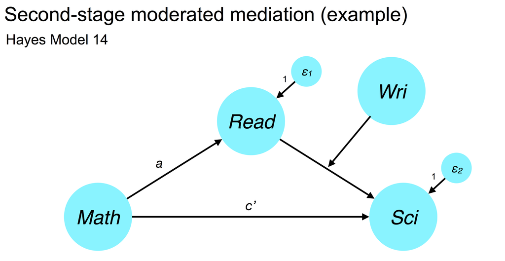

```r
#compute math x writing interaction term
df <- df %>% mutate(read_x_write = read_c*write_c)

moderated_mediation_stage2 <- '
  # regressions
    read_c ~ a*math_c
    science ~ b1*read_c
    science ~ b2*write_c
    science ~ b3*read_x_write
    science ~ cdash*math_c

  # mean of centered write (moderator; for use in simple slopes)
    write_c ~ write.mean*1

  # variance of centered write (moderator; for use in simple slopes)
    write_c ~~ write.var*write_c

  #index of moderated mediation
    imm := a*b3

  # indirect effects conditional on moderator (a1 + a3*b2.value)*a
    indirect.SDbelow := a*b1 + a*-sqrt(write.var)*b3
    indirect.mean := a*b1 + a*write.mean*b3
    indirect.SDabove := a*b1 + a*sqrt(write.var)*b3
'

# fit model
sem4 <- sem(model = moderated_mediation_stage2, data = df, se = "bootstrap", bootstrap = 1000)
# fit measures
summary(sem4, fit.measures = TRUE, standardize = TRUE, rsquare = TRUE)
```

```
## lavaan 0.6-3 ended normally after 43 iterations
##
##   Optimization method                           NLMINB
##   Number of free parameters                         16
##
##   Number of observations                           200
##
##   Estimator                                         ML
##   Model Fit Test Statistic                     133.763
##   Degrees of freedom                                 4
##   P-value (Chi-square)                           0.000
##
## Model test baseline model:
##
##   Minimum Function Test Statistic              390.617
##   Degrees of freedom                                 9
##   P-value                                        0.000
##
## User model versus baseline model:
##
##   Comparative Fit Index (CFI)                    0.660
##   Tucker-Lewis Index (TLI)                       0.235
##
## Loglikelihood and Information Criteria:
##
##   Loglikelihood user model (H0)              -1729.435
##   Loglikelihood unrestricted model (H1)      -1662.553
##
##   Number of free parameters                         16
##   Akaike (AIC)                                3490.870
##   Bayesian (BIC)                              3543.643
##   Sample-size adjusted Bayesian (BIC)         3492.953
##
## Root Mean Square Error of Approximation:
##
##   RMSEA                                          0.403
##   90 Percent Confidence Interval          0.346  0.463
##   P-value RMSEA <= 0.05                          0.000
##
## Standardized Root Mean Square Residual:
```

[output cut: 36 more lines]

```
##    .science          48.102    5.201    9.249    0.000   48.102    0.569
##     math_c            0.995    0.077   12.992    0.000    0.995    1.000
##     rd_x_wr           0.841    0.107    7.853    0.000    0.841    1.000
##
## R-Square:
##                    Estimate
##     read_c            0.439
##     science           0.431
##
## Defined Parameters:
##                    Estimate  Std.Err  z-value  P(>|z|)   Std.lv  Std.all
##     imm              -0.618    0.353   -1.751    0.080   -0.618   -0.062
##     indirect.SDblw    2.740    0.623    4.395    0.000    2.740    0.292
##     indirect.mean     2.124    0.485    4.375    0.000    2.124    0.230
##     indirect.SDabv    1.507    0.569    2.647    0.008    1.507    0.169
```

```r
#compute bias-corrected confidence intervals
parameterEstimates(sem3, boot.ci.type = "bca.simple", level = .95, ci = TRUE, standardized = FALSE)
```

| lhs | op | rhs | label | est | se | z | pvalue | ci.lower | ci.upper |
| --- | --- | --- | --- | --- | --- | --- | --- | --- | --- |
| read_c | ~ | math_c | a1 | 0.464 | 0.068 | 6.794 | 0.000 | 0.327 | 0.587 |
| science | ~ | read_c | b | 3.747 | 0.782 | 4.792 | 0.000 | 2.073 | 5.198 |
| read_c | ~ | write_c | a2 | 0.315 | 0.065 | 4.841 | 0.000 | 0.194 | 0.448 |
| read_c | ~ | math_x_write | a3 | 0.039 | 0.055 | 0.713 | 0.476 | -0.071 | 0.143 |
| science | ~ | math_c | cdash | 3.763 | 0.786 | 4.786 | 0.000 | 2.308 | 5.410 |
| write_c | ~1 |  | write.mean | 0.000 | 0.072 | 0.000 | 1.000 | -0.137 | 0.143 |
| write_c | ~~ | write_c | write.var | 0.995 | 0.080 | 12.390 | 0.000 | 0.838 | 1.160 |
| read_c | ~~ | read_c |  | 0.501 | 0.048 | 10.421 | 0.000 | 0.418 | 0.603 |
| science | ~~ | science |  | 50.894 | 5.095 | 9.988 | 0.000 | 42.058 | 62.922 |
| math_c | ~~ | math_c |  | 0.995 | 0.080 | 12.482 | 0.000 | 0.850 | 1.167 |
| math_c | ~~ | math_x_write |  | 0.110 | 0.086 | 1.283 | 0.200 | -0.056 | 0.274 |
| math_x_write | ~~ | math_x_write |  | 0.806 | 0.084 | 9.574 | 0.000 | 0.648 | 0.976 |
| read_c | ~1 |  |  | -0.024 | 0.066 | -0.363 | 0.717 | -0.150 | 0.097 |
| science | ~1 |  |  | 51.850 | 0.513 | 101.080 | 0.000 | 50.838 | 52.796 |
| math_c | ~1 |  |  | 0.000 | 0.071 | 0.000 | 1.000 | -0.143 | 0.142 |
| math_x_write | ~1 |  |  | 0.614 | 0.063 | 9.788 | 0.000 | 0.500 | 0.743 |
| imm | := | a3*b | imm | 0.146 | 0.211 | 0.690 | 0.490 | -0.259 | 0.600 |
| indirect.SDbelow | := | a1*b+a3*-sqrt(write.var)*b | indirect.SDbelow | 1.592 | 0.482 | 3.300 | 0.001 | 0.858 | 2.728 |
| indirect.mean | := | a1*b+a3*write.mean*b | indirect.mean | 1.737 | 0.393 | 4.425 | 0.000 | 1.026 | 2.575 |
| indirect.SDabove | := | a1*b+a3*sqrt(write.var)*b | indirect.SDabove | 1.883 | 0.406 | 4.631 | 0.000 | 1.086 | 2.729 |

# 6 Multiple-groups moderation

In a two-group case, treating moderator as a 0/1 variable is an easy way to handle mediation in SEM. When a moderating variable, $W$, is categorical, but has many levels (e.g., 5 groups), setting up dummy codes and computing all of the relevant interactions is very painful and laborious.

The better route is to treat the moderator $W$ as a grouping variable such that any path in the model could be moderated by group. This allows one to test categorical moderation of parameters not often considered in regression, such as latent variable variance estimates across groups.